## Stanford Databases Mini-Course DB4:

# Relational Algebra

### Notes by Leo Robinovitch

**Introduction:**

- Background terminology (from https://db.grussell.org/section010.html#_Toc67114481)
  - Relation - a set of tuples.
  - Tuple - a collection of attributes which describe some real world entity
    - Informally, an unordered set of linked values and heading-names in which each value has a type and is not Null
  - Attribute - a real world role played by a named domain.
  - Domain - a set of atomic values.
  - Set - a mathematical definition for a collection of objects which contains no duplicates.
  - Schema - set of attribute names
  - Expression - anything that results in a relation
- Example relations used in video: [Relation(columns)]
  - College(cName, state, enrollment)
  - Student(sID, sName, GPA, sizeHS)
  - Apply(sID, cName, major, decision)

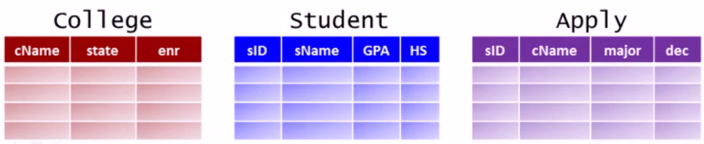

- Querying other relations results in a relation
- Key for a relation: a set of attributes whose values are guaranteed to be unique
- Simplest query in relational algebra is just the name of a relation
  - The query Student results in a copy of the relation Student

**Select Operator:** used to pick certain rows out of relation(s) $\to$ uses sigma $\sigma_{Condition}Relation$

- $\sigma_{GPA > 3.7}Student$ returns subset of student table containing those rows whose GPA is greater than 7
- $\sigma_{GPA > 3.7\ \wedge\ sizeHS < 1000}Student$ is intersection rows in Student where GPA > 3.7 and sizeHS < 1000
  - Note: $\wedge$ symbol means "and" in a condition (different than intersection $\cap$)
- $\sigma_{cName = 'Stanford'\ \wedge\ major = 'CS'}Apply$ gets applicants to Stanford in CS (rows of Apply)

**Project Operator:** used to pick certain columns out of relation(s) $\to$ uses pi: $\Pi_{Attributes A_1, A_2...A_n}Relation$ where attributes are column names

- $\Pi_{sID, decision}Apply$ gets out two columns (sID and decision) from Apply relation

**Sets vs. Multisets:**

- SQL: Multisets, bags $\to$ returns duplicates
- Relational Algebra: only returns sets, i.e. no duplicates

**Cross Product or Cartesian Product Operator $\mathbf{X}$:**

- Combines every possible pair of tuples from two relations
  - e.g. if relation A has N tuples and relation B has M tuples, $A X B$ has $N*M$ tuples

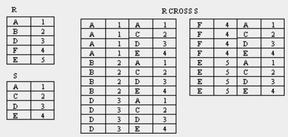

- Syntactic example: Names and GPAs of students with HS>1000 who applied to CS and were rejected (note: some column names have changed) $$\Pi_{Name, GPA}(\sigma_{Student.sID = Apply.sID\ \wedge\ HS > 1000\ \wedge\ major = 'CS'\ \wedge\ dec = 'R'}(Student\ X\ Apply))$$

**Natural Join Operator $\mathbf{\Join}$:**

- Smushes relations together horizontally, enforcing equality on all attributes (columns) with the same name and eliminating duplicate attributes (columns)

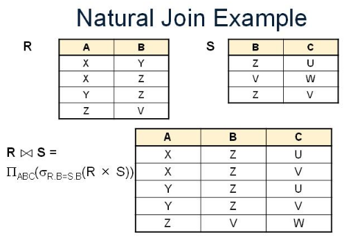

- Not actually doing anything we couldn't just do with cross product and select equality constraints, but convenient notationally
- Example: Names and GPAs of students with HS>1000 who applied to CS and were rejected at college with enr>20000 $$\Pi_{sName, GPA}(\sigma_{HS > 1000\ \wedge\ major = 'CS'\ \wedge\ dec = 'R'\ \wedge\ enr > 20000}(Student \Join Apply \Join College))$$

**Theta Join Operator $\mathbf{\Join_{\theta}}$:**

- Usually the one database people refer to when they say the "Join" operator
- Specifies the condition for which to keep rows after a cross product: $$Exp_1 \Join_{\theta} Exp_2 = \sigma_{\theta}(Exp_1\ X\ Exp_2)$$

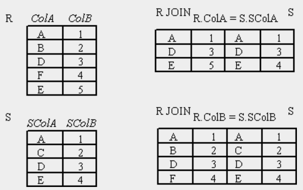

**Union Set Operator $\mathbf{\cup}$:**

- Can combine things "vertically"

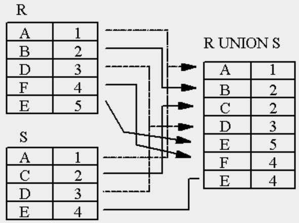

- Union Example: List of college and student names: $$\Pi_{cName}College\ \cup\ \Pi_{sName}Student$$
- Note that usually schemas (attribute names) are the same for union operator (take care of later)

**Difference Set Operator $\mathbf{-}$:**

- Deletes matching rows

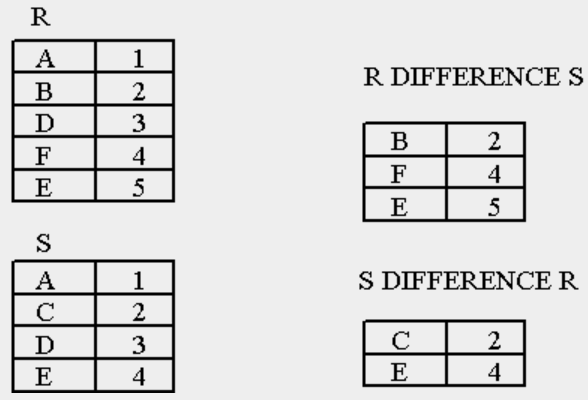

- Difference example: IDs of students who didn't apply anywhere: $$\Pi_{sID}Student - \Pi_{sID}Apply$$
- Can be slightly more complicated, e.g. names and IDs of students who didn't apply anywhere: $$\Pi_{sID, sName}((\Pi_{sID}Student - \Pi_{sID}Apply) \Join Student)$$

**Intersection Set Operator $\mathbf{\cap}$:**

- Returns intersection where schema and value are equal in two relations

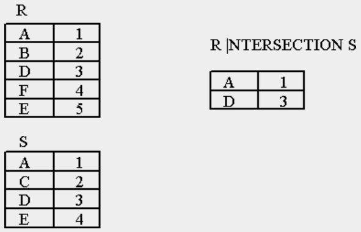

- Example: names that are both a college name and student name $$\Pi_{cName}College\ \cap\ \Pi_{sName}Student$$
  - Note that again, 2 sides of intersection should have same schema (take care of later)
- Intersection operator equivalent to:
  1. $E_1\ \cap\ E_2 \equiv E_1 - (E_1 - E_2)$
  2. $E_1\ \cap\ E_2 \equiv E_1 \Join E_2 \to$ when $E_1$ and $E_2$ have same schemas

**Assignment Statements:**

- Break down relational algebra statements into its parts
- E.g. pairs of colleges in same state:

\begin{align} C1 &:= \rho_{C1(n1, s, e1)} \\ C2 &:= \rho_{C2(n2, s, e2)} \\ CP &:= C1 \Join C2 \\ Ans &:= \sigma_{n1 < n2}CP \end{align}

**Expression Trees:**

- A visual representation of how SQL is compiled in a database system
- E.g. GPAs of students applying to CS in California (CA)

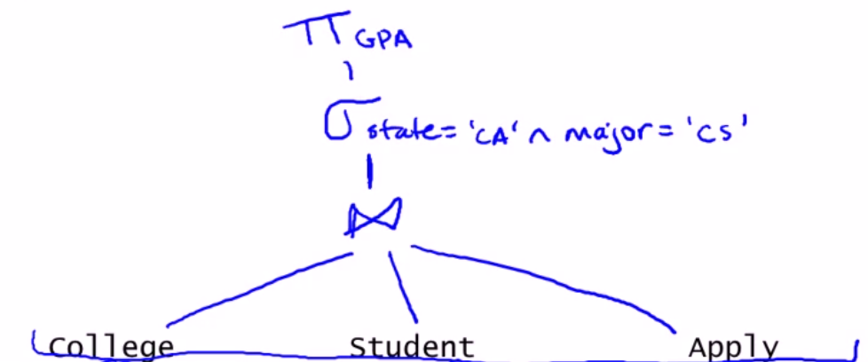

**Summary of Operators and Relational Algebra:**

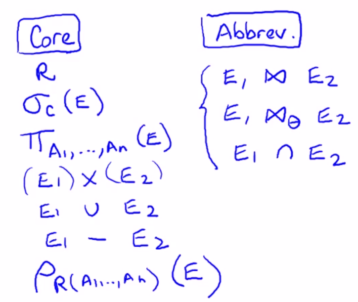

[output not shown]